# Cabbages

Marcia Alarcon

16 September 2021

# Introduction

The cabbages data from the MASS package is loaded into a dataframe called veggy. Complete this report by answering the following two questions

### Is there a difference in average VitC between c39 and c52 cultivation methods?

$H_0$: There is no difference in the amount of Vitamin C content of cabbages cultivated with methods c39 and c52.

$H_A$: There is a difference in the Vitamin C content based on cultivation method.

# Methods

VitC is a numerical variable. Cult is a categorical variable.So we need the helper file numerical~Cat.

# Results

## Descriptive Results

### Graphical Descriptive Results

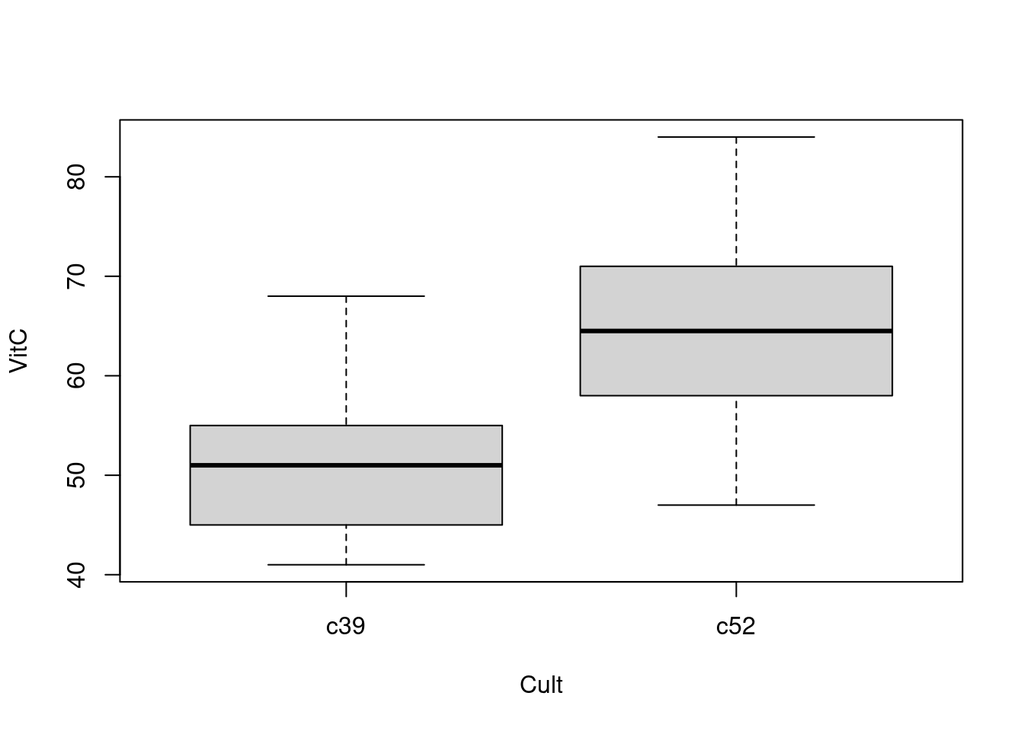

```r
boxplot(VitC~Cult,data=veggy)
```

This plot shows that in vitamin c cultivated with the content c39 is less effective then those cultivated with c52 content. The bottom of the barrel that contains vitamin c cultivated in c52 box is above the barrel for those with the vitamin c cultivated with c39 content.

### Numerical Descriptive Results

```r
favstats(VitC~Cult,data=veggy)
```

| Cult | min | Q1 | median | Q3 | max | mean | sd | n | missing |
| --- | --- | --- | --- | --- | --- | --- | --- | --- | --- |
| c39 | 41 | 46 | 51.0 | 54.75 | 68 | 51.5 | 7.123298 | 30 | 0 |
| c52 | 47 | 58 | 64.5 | 70.75 | 84 | 64.4 | 8.455156 | 30 | 0 |

This table shows that the content of vitamin c cultivated in with the method c39 average is 52 and the average content cultivated with c52 is 64.

## Inferential Results

```r
t.test(VitC~Cult,data=veggy)
```

```
##
##  Welch Two Sample t-test
##
## data:  VitC by Cult
## t = -6.3909, df = 56.376, p-value = 3.405e-08
## alternative hypothesis: true difference in means between group c39 and group c52 is not equal to 0
## 95 percent confidence interval:
##  -16.94296  -8.85704
## sample estimates:
## mean in group c39 mean in group c52
##              51.5              64.4
```

The p value is 0.00000003405 which is smaller than 0.05. There is a difference between the vitamin c content cultivated with c52 than in c39.

# Discussion and Conclusion

The original question is there a difference in the amount of Vitamin C content of cabbages based on cultivation methods c39 and c52. The boxplots show that there is a difference. The numerical summary showed the difference of c52 resulted in 13 more IUs. According to the research and the plots provided with the evidence of p value equaling to 0.00000003405 which is a very small number. This means that if the null hypothesis were true the likelihood of getting the result we found is so small that I reject the null hypothesis.